# Db2 Database Health Check

This Notebook is designed to gather the informaiton that can easily be gathered via database connection to perform a health check on a Db2 database. This notebook must be run separately for each Db2 database, even though it also includes some instance-level checks. While some checks are automated, most of them require human judgement - this notebook mostly just provides the data.

## Instructions for running

1. Install Jupyter Notebook using Anaconda (https://www.anaconda.com/distribution/)
   - Anaconda can be installed on your laptop or a vm on your laptop - anywhere you can connect to the databases in question. This works well if you are working with it alone, or have to connect to different vpns to connect to different databases
   - Anaconda can be installed on a central VM or server that can connect to the databases you wish to work with. This works well if you are working with a team of DBAs and only need to work with databases on that one network. Anaconda works just fine on Ubuntu if you are looking for a free option
   - Anaconda can be installed directly on the database server. This is generally my last choice, as I would rather not run an http server on my database server. I also rarely only care about one database server.
2. Copy this notebook to the computer you've installed Jupyter Notebook on. I'll refer to this as your Jupyter Notebook server.
3. Create a separate file to store enviornment variables. I've called mine ember_variables.py, and I run in in a cell below. This allows you to easily share the notebook without also sharing your ids and passwords and other sensative information. This also makes using git or other source control easy so you can keep notebooks updated across multiple locations. The format for this file is laid out below.
4. I strongly recommend using a table of contents via the nbextensions module to configure a table of contents to navigate this document. The options for this should appear on the bottom of the edit menu after you have installed the libraries in the first code cell.
5. Cells up through the database connection one should be run one by one to immediately detect and deal with errors. After the database connection cell, all further cells can be run using "Run All Below" from the Cell menu.

### Format for variables file

The ember_variables.py file has a format like this:

```
NA1_User='yourid'
NA1_PW='yourpw'

NA1_Host='server1.example.com'
NA1_insts = ('db2inst1', 'db2inst2', 'db2inst3', 'db2inst4')
NA1_ports = {'db2inst1': 50001, 'db2inst2': 50002, 'db2inst3':50003, 'db2inst4':50004}
NA1_dbs = {'db2inst1': ['SAMPLE1'], 'db2inst2': ['SAMPLE2'], 'db2inst3':['SAMPLE3'], 'db2inst4':['SAMPLE4','SAMPLE5']}
```

Feel free to structure things differently and if you have any good ideas in this area, please share them.

## Set up the enviornment

### Install Libraries

Run the following cell if it is the first time using this notebook on a specific jupyter notebook server. If anything is installed, restart the kernel using the 'Kernel' menu at the top of this notebook

```
sql magic, ibm_db and ibm_db_sa already installed.
jupyter_contrib_nbextensions is already installed.
```

Restart the Kernel if this is your first time installing the above. The next steps will fail unless you do this.

### Import the modules and load the SQL magic

Required each time the kernel for this notebook is started or restarted

### Set Basic Variables and Connect to Database

Connect to the database. Change the values in your variables file to match the environment you're connecting to. The format for this file is provided above.

```
'Connected: ecrooks@SAMPLE1'
```

After you have a successful connection, all further cells in this notebook can be executed using the "Run All Below" option on the Cell Menu

## Overall System Information

```
 * db2+ibm_db://ecrooks:***@192.0.2.10:50001/SAMPLE1
Done.
Returning data to local variable system_info
```

|  | os_name | host_name | os_full_version | os_kernel_version | os_arch_type | cpu_total | cpu_online | cpu_configured | cpu_speed | cpu_hmt_degree | cpu_cores_per_socket | memory_total | memory_free | virtual_mem_total | virtual_mem_reserved | virtual_mem_free | cpu_load_short | cpu_load_medium | cpu_load_long | cpu_usage_total | cpu_user | cpu_idle | cpu_iowait | cpu_system | swap_page_size | swap_pages_in | swap_pages_out |
| --- | --- | --- | --- | --- | --- | --- | --- | --- | --- | --- | --- | --- | --- | --- | --- | --- | --- | --- | --- | --- | --- | --- | --- | --- | --- | --- | --- |
| 0 | Linux | server1 | Red Hat Enterprise Linux Server 7.5 | 3.10.0-862.14.4.el7.x86_64 #1 SMP Fri Sep 21 0... | x86_64 | 40 | 40 | 40 | 2600 | 1 | 10 | 515693 | 3959 | 523885 | None | 12151 | 5.44 | 4.37 | 3.46 | 4 | 3044526788 | 62831918238 | 1456364579 | 837430094 | 4096 | 0 | 0 |

CHECK: Paging space is either 50% of physical memory or a maximum of 16 GB

Physical Memory:515693

Virtual Memory:8192

**Fail**: Virtual memory of **8192** is less than **16384**. It should be greater than or equal.

## Db2 Version and Fix Pack

```
 * db2+ibm_db://ecrooks:***@192.0.2.10:50001/SAMPLE1
Done.
Returning data to local variable level_info
```

|  | inst_name | is_inst_partitionable | num_dbpartitions | inst_ptr_size | release_num | service_level | bld_level | ptf | fixpack_num | num_members |
| --- | --- | --- | --- | --- | --- | --- | --- | --- | --- | --- |
| 0 | SAMPLE1 | 0 | 1 | 64 | 0609010E | DB2 v10.5.0.8 | s160901 | IP23993 | 8 | 1 |

## Db2 Licensed Product(s)

```
 * db2+ibm_db://ecrooks:***@192.0.2.10:50001/SAMPLE1
Done.
Returning data to local variable license_info
```

```
<class 'pandas.core.series.Series'>
<class 'pandas.core.series.Series'>
<class 'pandas.core.series.Series'>
<class 'pandas.core.series.Series'>
```

|  | installed_prod | installed_prod_fullname | license_installed | prod_release | license_type |
| --- | --- | --- | --- | --- | --- |
| 0 | ESE | DB2_ENTERPRISE_SERVER_EDITION | Y | 10.5 | RESTRICTED |
| 1 | AESE | DB2_ADVANCED_ENTERPRISE_SERVER_EDITION | N | 10.5 | None |
| 2 | AWSE | DB2_ADVANCED_WORKGROUP_SERVER_EDITION | N | 10.5 | None |
| 3 | WSE | DB2_WORKGROUP_SERVER_EDITION | N | 10.5 | None |

## Db2 Configuration

### Db2 Registry

```
 * db2+ibm_db://ecrooks:***@192.0.2.10:50001/SAMPLE1
Done.
Returning data to local variable registry_settings
```

| reg_var_name | reg_var_value | is_aggregate | aggregate_name | level |
| --- | --- | --- | --- | --- |
| DB2CODEPAGE | 1208 | 0 | None | I |
| DB2COMM | TCPIP | 0 | None | I |
| DB2DBDFT | SAMPLE1 | 0 | None | E |
| DB2SYSTEM | server1 | 0 | None | G |
| DB2BIDI | yes | 0 | None | I |
| DB2_SKIPDELETED | YES | 0 | DB2_WORKLOAD | I |
| DB2_ANTIJOIN | EXTEND | 0 | DB2_WORKLOAD | I |
| DB2_EVALUNCOMMITTED | YES | 0 | DB2_WORKLOAD | I |
| DB2_REDUCED_OPTIMIZATION | INDEX,UNIQUEINDEX,JOIN,NO_SORT_MGJOIN | 0 | DB2_WORKLOAD | I |
| DB2_MINIMIZE_LISTPREFETCH | YES | 0 | DB2_WORKLOAD | I |
| DB2_INLIST_TO_NLJN | YES | 0 | DB2_WORKLOAD | I |
| DB2_OPTPROFILE | YES | 0 | DB2_WORKLOAD | I |
| DB2_SKIPINSERTED | YES | 0 | DB2_WORKLOAD | I |
| DB2_WORKLOAD | WC | 1 | None | I |
| DB2_OPT_MAX_TEMP_SIZE | 10240 | 0 | DB2_WORKLOAD | I |
| DB2_HADR_ROS | ON | 0 | None | I |
| DB2_RESTORE_GRANT_ADMIN_AUTHORITIES | YES | 0 | None | I |

### DBM CFG

```
 * db2+ibm_db://ecrooks:***@192.0.2.10:50001/SAMPLE1
Done.
Returning data to local variable dbm_settings
```

| name | VALUE | value_flags | deferred_value | deferred_value_flags |
| --- | --- | --- | --- | --- |
| agent_stack_sz | 1024 | NONE | 1024 | NONE |
| agentpri | -1 | NONE | -1 | NONE |
| aslheapsz | 15 | NONE | 15 | NONE |
| audit_buf_sz | 0 | NONE | 0 | NONE |
| authentication | SERVER | NONE | SERVER | NONE |
| catalog_noauth | NO | NONE | NO | NONE |
| clnt_krb_plugin | None | NONE | None | NONE |
| clnt_pw_plugin | None | NONE | None | NONE |
| cluster_mgr | TSA | NONE | TSA | NONE |
| comm_bandwidth | 1.000000e+02 | NONE | 1.000000e+02 | NONE |
| conn_elapse | 10 | NONE | 10 | NONE |
| cpuspeed | 1.731929e-07 | NONE | 1.731929e-07 | NONE |
| dft_account_str | None | NONE | None | NONE |
| dft_mon_bufpool | ON | NONE | ON | NONE |
| dft_mon_lock | ON | NONE | ON | NONE |
| dft_mon_sort | ON | NONE | ON | NONE |
| dft_mon_stmt | ON | NONE | ON | NONE |
| dft_mon_table | ON | NONE | ON | NONE |
| dft_mon_timestamp | ON | NONE | ON | NONE |
| dft_mon_uow | OFF | NONE | OFF | NONE |
| dftdbpath | /db2/SAMPLE1 | NONE | /db2/SAMPLE1 | NONE |
| diaglevel | 3 | NONE | 3 | NONE |
| diagpath | /db2/SAMPLE1/db2dump/ | NONE | /db2/SAMPLE1/db2dump/ | NONE |
| diagpath_resolved | /db2/SAMPLE1/db2dump/ | NONE | /db2/SAMPLE1/db2dump/ | NONE |
| dir_cache | YES | NONE | YES | NONE |
| discover | SEARCH | NONE | SEARCH | NONE |
| discover_inst | ENABLE | NONE | ENABLE | NONE |
| fcm_num_buffers | 4096 | AUTOMATIC | 4096 | AUTOMATIC |
| fed_noauth | NO | NONE | NO | NONE |
| federated | NO | NONE | NO | NONE |

[output cut: 78 more lines]

#### Automatic Checks for DBM CFG

**WARNING** Deferred value not in effect! WLM_DISP_CONCUR value of **160** and deferred value of **-1** are different!

```
DIAGLEVEL is 3
NOTIFYLEVEL is 3
AUTHENTICATION is SERVER
```

**WARNING** SVCENAME is 50001. This is a number, and it is better to set SVCENAME to a service name that is defined in /etc/services.

**WARNING** SVCENAME is 50001. This number is an often-used default.

```
SYSMON_GROUP is ECROOKS .
```

#### DBM CFG Values to Pay Special Attention to in Manual Verification

INTRA_PARALLEL value of NO

INSTANCE_MEMORY value of 52428800 4K pages, automatic setting of NONE

DFT_MON settings:

```
DFT_MON_BUFPOOL		=ON
DFT_MON_LOCK		=ON
DFT_MON_SORT		=ON
DFT_MON_STMT		=ON
DFT_MON_TABLE		=ON
DFT_MON_TIMESTAMP	=ON
DFT_MON_UOW		=OFF
```

System groups:

```
SYSADM_GROUP		=DB2IADM1
SYSCTRL_GROUP		=None
SYSMAINT_GROUP		=None
SYSMON_GROUP		=ECROOKS
```

## DB CFG

```
 * db2+ibm_db://ecrooks:***@192.0.2.10:50001/SAMPLE1
Done.
Returning data to local variable db_settings
```

Database Configuration Information for SAMPLE1 on SAMPLE1

#### Automatic Checks for this Database

LOCKTIMEOUT is 45.

**WARNING** TRACKMOD is set to NO.

DFT_QUERYOPT is 5

DFT_DEGREE is 1

LOGSECOND is 181

#### Manual Checks for this database

STMT_CONC is set to OFF

CUR_COMMIT is set to ON

ENCRYPTED_DATABASE is set to NO

Settings related to STMM :

SELF_TUNING_MEM is set to ON (Active)

```
	INSTANCE_MEMORY is set to 52428800 - NONE
	DATABASE_MEMORY is set to 49154934 - AUTOMATIC
	SHEAPTHRES_SHR is set to 1708681 - AUTOMATIC
	SHEAPTHRES is set to 0 - NONE
	SORTHEAP is set to 50000 - AUTOMATIC
	PCKCACHESZ is set to 131072 - NONE
 * db2+ibm_db://ecrooks:***@192.0.2.10:50001/SAMPLE1
Done.
              PAGESIZE  cur_bp_size_mb  automatic
bp_name
IBMDEFAULTBP      4096          125026  AUTOMATIC
BUFF8K            8192           27637  AUTOMATIC
BUFF16K          16384            3591  AUTOMATIC
BUFF32K          32768              31  AUTOMATIC
```

Automatic Maintenance:

AUTO_MAINT is set to ON

```
AUTO_DB_BACKUP is set to OFF
```

```
AUTO_TBL_MAINT is set to ON
```

```
    AUTO_RUNSTATS is set to ON
```

```
        AUTO_STMT_STATS is set to ON
```

```
        AUTO_STATS_VIEWS is set to OFF
```

```
        AUTO_SAMPLING is set to OFF
```

```
    AUTO_REORG is set to OFF
```

| name | VALUE | value_flags | deferred_value | deferred_value_flags |
| --- | --- | --- | --- | --- |
| app_ctl_heap_sz | 256 | NONE | 256 | NONE |
| appgroup_mem_sz | 30000 | NONE | 30000 | NONE |
| applheapsz | 256 | AUTOMATIC | 256 | AUTOMATIC |
| archretrydelay | 20 | NONE | 20 | NONE |
| auto_del_rec_obj | OFF | NONE | OFF | NONE |
| auto_maint | ON | NONE | ON | NONE |
| auto_db_backup | OFF | NONE | OFF | NONE |
| auto_tbl_maint | ON | NONE | ON | NONE |
| auto_runstats | ON | NONE | ON | NONE |
| auto_stmt_stats | ON | NONE | ON | NONE |
| auto_stats_views | OFF | NONE | OFF | NONE |
| auto_sampling | OFF | NONE | OFF | NONE |
| auto_reorg | OFF | NONE | OFF | NONE |
| autorestart | ON | NONE | ON | NONE |
| auto_reval | DEFERRED | NONE | DEFERRED | NONE |
| avg_appls | 1 | AUTOMATIC | 1 | AUTOMATIC |
| blk_log_dsk_ful | NO | NONE | NO | NONE |
| blocknonlogged | YES | NONE | YES | NONE |
| catalogcache_sz | 4096 | NONE | 4096 | NONE |
| chngpgs_thresh | 80 | NONE | 80 | NONE |
| database_memory | 49154934 | AUTOMATIC | 49154934 | AUTOMATIC |
| dbheap | 20736 | AUTOMATIC | 20736 | AUTOMATIC |
| dft_degree | 1 | NONE | 1 | NONE |
| dft_extent_sz | 32 | NONE | 32 | NONE |
| dft_loadrec_ses | 1 | NONE | 1 | NONE |
| dft_mttb_types | SYSTEM | NONE | SYSTEM | NONE |
| dft_prefetch_sz | 32 | AUTOMATIC | 32 | AUTOMATIC |
| dft_queryopt | 5 | NONE | 5 | NONE |
| dft_refresh_age | 0 | NONE | 0 | NONE |
| dft_sqlmathwarn | NO | NONE | NO | NONE |

[output cut: 135 more lines]

## Memory

### Current Memory Layout

```
 * db2+ibm_db://ecrooks:***@192.0.2.10:50001/SAMPLE1
Done.
Returning data to local variable inst_memory
```

Current Memory Layout for SAMPLE1

| memory_set | used_mb |
| --- | --- |
| APPLICATION SAMPLE1 | 117 |
| DATABASE SAMPLE1 | 169530 |
| None | 144 |
| None | 2 |
| None | 315 |

```
<function matplotlib.pyplot.show(*args, **kw)>
```

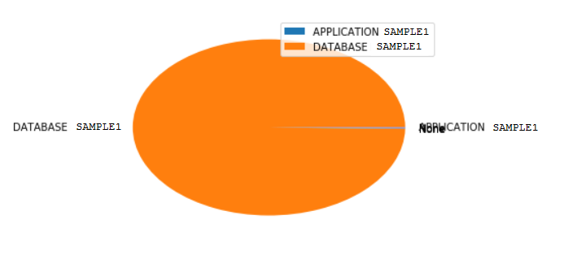

```
 * db2+ibm_db://ecrooks:***@192.0.2.10:50001/SAMPLE1
Done.
Returning data to local variable db_memory
```

Current Memory Layout for SAMPLE1 on SAMPLE1

| memory_pool | used_mb |
| --- | --- |
| APPLICATION APPLICATION | 59 |
| APPLICATION APPL_SHARED | 46 |
| DATABASE BP | 165951 |
| DATABASE CAT_CACHE | 21 |
| DATABASE DATABASE | 309 |
| DATABASE LOCK_MGR | 2781 |
| DATABASE PACKAGE_CACHE | 412 |
| DATABASE SHARED_SORT | 2 |
| DATABASE UTILITY | 0 |
| DATABASE XMLCACHE | 0 |

```
<function matplotlib.pyplot.show(*args, **kw)>
```

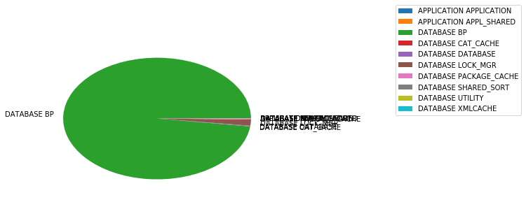

### Layout with Maximum Sort

Sort memory is only allocated as needed. This diagram uses the maximum possible sort allocation to understand the balance when sorts are occurring.

```
2.0
```

| memory_pool | used_mb |
| --- | --- |
| APPLICATION APPLICATION | 59.000000 |
| APPLICATION APPL_SHARED | 46.000000 |
| DATABASE BP | 165951.000000 |
| DATABASE CAT_CACHE | 21.000000 |
| DATABASE DATABASE | 309.000000 |
| DATABASE LOCK_MGR | 2781.000000 |
| DATABASE PACKAGE_CACHE | 412.000000 |
| DATABASE SHARED_SORT | 6674.535156 |
| DATABASE UTILITY | 0.000000 |
| DATABASE XMLCACHE | 0.000000 |

```
<function matplotlib.pyplot.show(*args, **kw)>
```

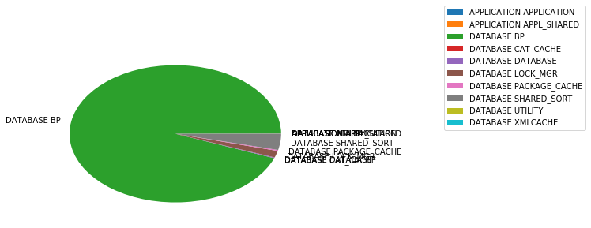

### Memory Breakdown by Buffer Pool

```
 * db2+ibm_db://ecrooks:***@192.0.2.10:50001/SAMPLE1
Done.
Returning data to local variable bp_sizes
```

```
 * db2+ibm_db://ecrooks:***@192.0.2.10:50001/SAMPLE1
Done.
Returning data to local variable bp_grp_sizes
```

Buffer Pool Layout for SAMPLE1 on SAMPLE1

Buffer Pools by size

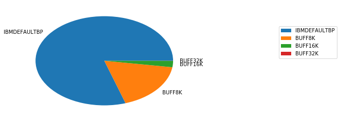

|  | bp_name | PAGESIZE | cur_bp_size_mb | automatic |
| --- | --- | --- | --- | --- |
| 0 | IBMDEFAULTBP | 4096 | 125026.0 | AUTOMATIC |
| 1 | BUFF8K | 8192 | 27637.0 | AUTOMATIC |
| 2 | BUFF16K | 16384 | 3591.0 | AUTOMATIC |
| 3 | BUFF32K | 32768 | 31.0 | AUTOMATIC |

Grouping Small Buffer Pools for Better Display

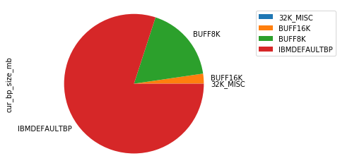

| bp_name | cur_bp_size_mb |
| --- | --- |
| 32K_MISC | 31 |
| BUFF16K | 3591 |
| BUFF8K | 27637 |
| IBMDEFAULTBP | 125026 |

## Security

```
Security Information for  SAMPLE1  on  SAMPLE1
```

### IDs with SECADM

```
 * db2+ibm_db://ecrooks:***@192.0.2.10:50001/SAMPLE1
Done.
Returning data to local variable secadm_ids
```

| grantee |
| --- |
| DB2INST1 |
| SAMPLE1 |
| DBUSER1 |
| DB2INST1 |

### IDs with DBADM

```
 * db2+ibm_db://ecrooks:***@192.0.2.10:50001/SAMPLE1
Done.
Returning data to local variable dbadm_ids
```

| grantee |
| --- |
| DB2INST1 |
| SAMPLE1 |
| DBUSER1 |
| DB2INST1 |
| VDBA |

### IDs with DATAACCESS

```
 * db2+ibm_db://ecrooks:***@192.0.2.10:50001/SAMPLE1
Done.
Returning data to local variable dataaccess_ids
```

| grantee |
| --- |
| DB2INST1 |
| DBUSER2 |
| ECROOKS |
| DBUSER3 |
| DBUSER4 |
| SAMPLE1 |
| DBUSER5 |
| DBUSER1 |
| DB2INST1 |
| ECROOKS |
| DBUSER2 |
| DBUSER6 |
| DBUSER7 |
| DBUSER8 |
| DBUSER9 |
| DBUSER10 |
| DBUSER11 |
| DBUSER12 |
| OPSVIEW |
| DB2WRITE |

### Privileges held by PUBLIC

```
 * db2+ibm_db://ecrooks:***@192.0.2.10:50001/SAMPLE1
Done.
Returning data to local variable public_perms
```

```
 * db2+ibm_db://ecrooks:***@192.0.2.10:50001/SAMPLE1
Done.
Returning data to local variable public_connect
```

List of public permissions minus those on the system catalog and packages granted with the "grant public" keywords on bind for db2cli and db2ubind

| privilege | objecttype | objectschema | objectname |
| --- | --- | --- | --- |
| CREATEIN | SCHEMA | SAMPLE1 |  |
| CREATEIN | SCHEMA | DB2INST1 |  |
| CREATEIN | SCHEMA | DBA |  |
| CREATEIN | SCHEMA | ECROOKS |  |
| CREATEIN | SCHEMA | NEWTON |  |
| CREATEIN | SCHEMA | VDBA |  |
| USE | TABLESPACE |  | SYSTOOLSTMPSPACE |
| USE | TABLESPACE |  | SYSTOOLSTMPSPACE |
| USE | TABLESPACE |  | USERSPACE1 |
| USAGE | WORKLOAD |  | SYSDEFAULTUSERWORKLOAD |

## Database Objects

```
 * db2+ibm_db://ecrooks:***@192.0.2.10:50001/SAMPLE1
Done.
Returning data to local variable list_evms
```

### Event Monitors

| evmonname | status | target_type | target | autostart | versionnumber |
| --- | --- | --- | --- | --- | --- |
| MY_LOCKS | ACTIVE | U |  | Y | 10050800 |

### Explain Tables

```
 * db2+ibm_db://ecrooks:***@192.0.2.10:50001/SAMPLE1
Done.
Returning data to local variable expln_schemas
```

| tabschema | count_tables |
| --- | --- |
| SYSTOOLS | 16 |

Verifying Explain Schema for SYSTOOLS

```
 * db2+ibm_db://ecrooks:***@192.0.2.10:50001/SAMPLE1
Done.
 * db2+ibm_db://ecrooks:***@192.0.2.10:50001/SAMPLE1
Done.
```

| tabschema | count_tables | Valid | last_explain_time |
| --- | --- | --- | --- |
| SYSTOOLS | 16 | Yes | 2019-04-18 09:12:49.593215 |

```
 * db2+ibm_db://ecrooks:***@192.0.2.10:50001/SAMPLE1
Done.
Returning data to local variable list_bps
```

### Buffer Pools

#### List of Buffer Pools

| bp_name | bp_cur_buffsz | PAGESIZE | sz_mb | total_logical_reads | total_physical_reads | data_hit_ratio_percent | tablespaces |
| --- | --- | --- | --- | --- | --- | --- | --- |
| IBMDEFAULTBP | 32006666 | 4096 | 125026 | 6691157366873 | 127225127 | 99.99 | SYSCATSPACE TEMPSPACE1 USERSPACE1 SYSTOOLSPACE SYSTOOLSTMPSPACE |
| BUFF8K | 3537592 | 8192 | 27637 | 27575638219 | 50680259 | 99.99 | TAB8K TEMPSYS8K |
| BUFF16K | 229856 | 16384 | 3591 | 5189059397 | 574106 | 99.99 | TAB16K TEMPSYS16K |
| BUFF32K | 1000 | 32768 | 31 | 57234240 | 257414 | 99.99 | TEMPSYS32K TAB32K |

#### Buffer Pool Hit Ratios by Tablespace

```
 * db2+ibm_db://ecrooks:***@192.0.2.10:50001/SAMPLE1
Done.
Returning data to local variable ts_bp_hitratios
```

| tbsp_name | 2 |
| --- | --- |
| SYSCATSPACE | 99.99 |
| TEMPSPACE1 | 100.00 |
| USERSPACE1 | 99.99 |
| SYSTOOLSPACE | 99.99 |
| SYSTOOLSTMPSPACE | 100.00 |
| TAB8K | 99.99 |
| TEMPSYS8K | 100.00 |
| TAB16K | 99.99 |
| TEMPSYS16K | 100.00 |
| TEMPSYS32K | 99.99 |
| TAB32K | 99.99 |

#### Tables/Table Spaces by Buffer Pool

```
 * db2+ibm_db://ecrooks:***@192.0.2.10:50001/SAMPLE1
Done.
Returning data to local variable bp_tables
```

#### All Buffer Pools

|  | bpname | bufferpoolid | ts_count | tab_count |
| --- | --- | --- | --- | --- |
| 0 | IBMDEFAULTBP | 1 | 5 | 1400 |
| 1 | BUFF8K | 2 | 2 | 132 |
| 2 | BUFF16K | 3 | 2 | 59 |
| 3 | BUFF32K | 4 | 2 | 1 |

#### Unused Bufferpools

|  | bpname | bufferpoolid | ts_count | tab_count |
| --- | --- | --- | --- | --- |

#### Comparing Buffer Pools

```
 * db2+ibm_db://ecrooks:***@192.0.2.10:50001/SAMPLE1
Done.
Returning data to local variable bp_compare
```

```
<function matplotlib.pyplot.show(*args, **kw)>
```

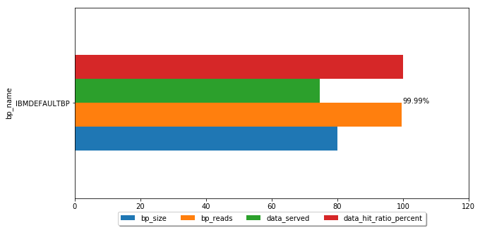

### Table Spaces

#### Database Size by Pages in Table Spaces

```
 * db2+ibm_db://ecrooks:***@192.0.2.10:50001/SAMPLE1
Done.
```

| data_size_gb |
| --- |
| 129 |

#### Count of Table Spaces

```
 * db2+ibm_db://ecrooks:***@192.0.2.10:50001/SAMPLE1
Done.
```

| num_tbsps |
| --- |
| 11 |

#### Table Space Details

```
 * db2+ibm_db://ecrooks:***@192.0.2.10:50001/SAMPLE1
Done.
Returning data to local variable list_tbsps
```

#### Potentially Wasted Space in Table Spaces

```
 * db2+ibm_db://ecrooks:***@192.0.2.10:50001/SAMPLE1
Done.
Returning data to local variable tbsps_space_waste
```

Easily Reclaimable Space in MB

```
107
```

Table Spaces With More Than 100 MB to Reclaim

|  | auto_resize | page_size | ts_mb | pct_used | tbsp_extent_size | tbsp_freeable_pgs | freeable_mb | free_mb_sm_ext | reclaimable |
| --- | --- | --- | --- | --- | --- | --- | --- | --- | --- |
| tbsp_name |  |  |  |  |  |  |  |  |  |

Reclaimable Space with Smaller Extent in MB

```
0
```

Table Spaces that are Not Reclaimable

|  | auto_resize | page_size | ts_mb | pct_used | tbsp_extent_size | tbsp_freeable_pgs | freeable_mb | free_mb_sm_ext | reclaimable |
| --- | --- | --- | --- | --- | --- | --- | --- | --- | --- |
| tbsp_name |  |  |  |  |  |  |  |  |  |

Table Spaces that are Nearly Full

|  | tbsp_type | TYPE | tabcount | auto_sto | auto_resize | page_size | used_pages | total_pages | ts_gb | space_check | maxsize_thresh |
| --- | --- | --- | --- | --- | --- | --- | --- | --- | --- | --- | --- |
| tbsp_name |  |  |  |  |  |  |  |  |  |  |  |

Table Spaces that are Not Using AST

|  | tbsp_type | TYPE | tabcount | auto_sto | auto_resize | page_size | used_pages | total_pages | ts_gb | space_check | maxsize_thresh |
| --- | --- | --- | --- | --- | --- | --- | --- | --- | --- | --- | --- |
| tbsp_name |  |  |  |  |  |  |  |  |  |  |  |

Table Spaces that are Not Using Automatic Resize

|  | tbsp_type | TYPE | tabcount | auto_sto | auto_resize | page_size | used_pages | total_pages | ts_gb | space_check | maxsize_thresh |
| --- | --- | --- | --- | --- | --- | --- | --- | --- | --- | --- | --- |
| tbsp_name |  |  |  |  |  |  |  |  |  |  |  |

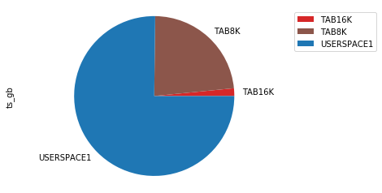

### Grouping tablespaces for better display

```
 * db2+ibm_db://ecrooks:***@192.0.2.10:50001/SAMPLE1
Done.
Returning data to local variable large_tbsps
```

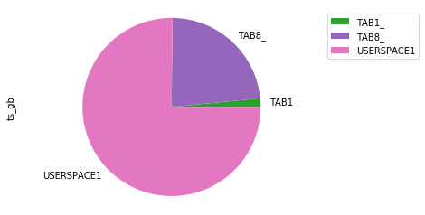

| tbsp_name | tbsp_type | TYPE | tabcount | auto_sto | auto_resize | page_size | used_pages | total_pages | ts_gb | space_check | maxsize_thresh |
| --- | --- | --- | --- | --- | --- | --- | --- | --- | --- | --- | --- |
| SYSCATSPACE | DMS | ANY | 144 | 1 | 1 | 4096 | 104372 | 104400 | 0.0 | EXCLUDE | 64 |
| SYSTOOLSPACE | DMS | LARGE | 23 | 1 | 1 | 4096 | 14552 | 16400 | 0.0 | EXCLUDE | 8192 |
| SYSTOOLSTMPSPACE | SMS | USRTEMP | 0 | 1 | 0 | 4096 | 5 | 5 | 0.0 | EXCLUDE | EXCLUDE |
| TAB16K | DMS | ANY | 59 | 1 | 1 | 16384 | 188768 | 188960 | 2.0 | EXCLUDE | 256 |
| TAB32K | DMS | LARGE | 1 | 1 | 1 | 32768 | 544 | 800 | 0.0 | EXCLUDE | 65536 |
| TAB8K | DMS | LARGE | 132 | 1 | 1 | 8192 | 3987264 | 3990880 | 30.0 | EXCLUDE | 16384 |
| TEMPSPACE1 | SMS | SYSTEMP | 0 | 1 | 0 | 4096 | 2006 | 2006 | 0.0 | EXCLUDE | EXCLUDE |
| TEMPSYS16K | SMS | SYSTEMP | 0 | 1 | 0 | 16384 | 5 | 5 | 0.0 | EXCLUDE | EXCLUDE |
| TEMPSYS32K | SMS | SYSTEMP | 0 | 1 | 0 | 32768 | 36 | 36 | 0.0 | EXCLUDE | EXCLUDE |
| TEMPSYS8K | SMS | SYSTEMP | 0 | 1 | 0 | 8192 | 5 | 5 | 0.0 | EXCLUDE | EXCLUDE |
| USERSPACE1 | DMS | LARGE | 1233 | 1 | 1 | 4096 | 25651520 | 25667360 | 97.0 | EXCLUDE | 8192 |

| tbsp_name | auto_resize | page_size | ts_mb | pct_used | tbsp_extent_size | tbsp_freeable_pgs | freeable_mb | free_mb_sm_ext | reclaimable |
| --- | --- | --- | --- | --- | --- | --- | --- | --- | --- |
| SYSCATSPACE | 1 | 4096 | 407 | 99.00 | 4 | 28 | 0 | 0 | 1 |
| SYSTOOLSPACE | 1 | 4096 | 64 | 88.00 | 4 | 1848 | 7 | 0 | 1 |
| TAB16K | 1 | 16384 | 2952 | 99.00 | 32 | 192 | 3 | 0 | 1 |
| TAB32K | 1 | 32768 | 25 | 68.00 | 32 | 256 | 8 | 0 | 1 |
| TAB8K | 1 | 8192 | 31178 | 99.00 | 32 | 3616 | 28 | 0 | 1 |
| USERSPACE1 | 1 | 4096 | 100263 | 99.00 | 32 | 15840 | 61 | 0 | 1 |

## Database Size

```
 * db2+ibm_db://ecrooks:***@192.0.2.10:50001/SAMPLE1
Done.
```

```
[]
```

### Indexes

Indexes in SAMPLE1 on SAMPLE1

#### Indexes with a cardinality of one

```
 * db2+ibm_db://ecrooks:***@192.0.2.10:50001/SAMPLE1
Done.
Returning data to local variable card1_indexes
```

| lastused | tabschema | tabname | indname | colnames | fullkeycard | card | VOLATILE |
| --- | --- | --- | --- | --- | --- | --- | --- |
| 2019-04-06 | DB2INST1 | CATENTRY | I0000375 | +RANK | 1 | 1,146,590 |  |
| 2018-12-22 | DB2INST1 | CATGROUP | I0000376 | +RANK | 1 | 4,065 |  |
| 0001-01-01 | DB2INST1 | STLOC | I0001210 | +LATITUDE +LONGITUDE | 1 | 1 |  |
| 2016-09-07 | DB2INST1 | CATENTDESCOVR | IPF00031 | +UP_NAME | 1 | 1 |  |
| 2018-09-28 | DB2INST1 | SRCHATTRDESC | IPF00035 | +UP_DESCRIPTION | 1 | 227 |  |
| 2014-10-29 | DB2INST1 | TI_DELTA_CATGROUP | TI_DELTA_CATGROUP_DB2INST1_0 | +LASTUPDATE | 1 | 1 |  |
| 2018-06-07 | DB2INST1 | TI_DELTA_CATGROUP | TI_DELTA_CATGROUP_DB2INST1_1 | +MASTERCATALOG_ID +LASTUPDATE | 1 | 1 |  |
| 2019-04-30 | DB2INST1 | TI_DELTA_CATGROUP | TI_DELTA_CATGROUP_DB2INST1_2 | +MASTERCATALOG_ID +ACTION | 1 | 1 |  |

#### Indexes not used in the last 30 days

```
 * db2+ibm_db://ecrooks:***@192.0.2.10:50001/SAMPLE1
Done.
Returning data to local variable unused_indexes
```

| lastused | tabschema | tabname | indname | colnames | fullkeycard | table_card | index_scans | index_only_scans | VOLATILE |
| --- | --- | --- | --- | --- | --- | --- | --- | --- | --- |
| 2018-11-17 | SAMPLE1 | LOCK_EVENT | LOCK_EVENT_IND1 | +XMLID | 19,198 | 19,198 | 1 | 0 |  |
| 2018-11-26 | SAMPLE1 | LOCK_PARTICIPANTS | LOCK_PARTICIPANTS_IND1 | +XMLID +PARTICIPANT_NO | 38,396 | 38,396 | 7 | 0 |  |
| 0001-01-01 | DB2INST1 | GRGFTREG | GRG_CONSTRAINT1 | +STOREID | 4 | 86,588 | 0 | 0 |  |
| 2014-03-06 | DB2INST1 | SUBORDERS | I0000242 | +TOTALPRODUCT | 64,588 | 3,800,063 | 0 | 0 |  |
| 2016-06-22 | DB2INST1 | NOTIFY | I0000307 | +NOTIFICATIONID | 2,559,080 | 2,559,081 | 0 | 0 |  |
| 2018-12-26 | DB2INST1 | COUNTRY | I0000343 | +NAME | 2,420 | 3,196 | 2 | 0 |  |
| 2018-09-28 | DB2INST1 | BUSAUDIT | I0000374 | +SESSION_ID +SEQUENCE | 200,560 | 202,596 | 0 | 0 |  |
| 2019-04-06 | DB2INST1 | CATENTRY | I0000375 | +RANK | 1 | 1,146,590 | 36113 | 36113 |  |
| 2018-12-22 | DB2INST1 | CATGROUP | I0000376 | +RANK | 1 | 4,065 | 71 | 71 |  |
| 0001-01-01 | DB2INST1 | STLOC | I0001210 | +LATITUDE +LONGITUDE | 1 | 1 | 0 | 0 |  |
| 2019-03-04 | DB2INST1 | EDPPAYINST | I0000845 | +BACKENDPIID | 3,869,557 | 3,869,557 | 36 | 0 |  |
| 2018-09-02 | DB2INST1 | ORDERS | I0000933 | +SOURCEID | 2 | 4,242,865 | 0 | 0 |  |
| 2018-09-28 | DB2INST1 | CMFILE | I0000934 | +CMFILEDIR_ID | 2 | 161 | 0 | 0 |  |
| 2018-09-28 | DB2INST1 | PPCEXTDATA | I0000962 | +SEARCHVALUE | 10,002 | 74,437,568 | 0 | 0 |  |
| 2018-09-28 | DB2INST1 | DMTRIGLSTN | I0001152 | +NAME +STOREENT_ID | 7 | 7,069 | 0 | 0 |  |
| 2018-09-28 | DB2INST1 | DMTRIGLSTN | I0001154 | +STOREENT_ID | 7 | 7,069 | 0 | 0 |  |
| 2017-11-22 | DB2INST1 | DMEMSPOTSTATS | I0001155 | +EMSPOT_ID | 10,897 | 27,465 | 0 | 0 |  |
| 2019-04-04 | DB2INST1 | DMEMSPOTDEF | I0001164 | +STOREENT_ID | 9 | 12,138 | 106 | 106 |  |
| 2017-11-10 | DB2INST1 | DMACTIVITY | I0001193 | +STARTDATE | 924 | 7,160 | 0 | 0 |  |
| 0001-01-01 | DB2INST1 | ATCHTGTDSC | I0001208 | +NAME | 113 | 159 | 0 | 0 |  |
| 2018-12-20 | DB2INST1 | PX_PROMOAUTH | I0001219 | +ADMINSTVENAME | 2,901 | 2,908 | 7 | 0 |  |
| 0001-01-01 | DB2INST1 | SRCHSTAT | I0001391 | +KEYWORD +LANGUAGE_ID +STOREENT_ID +KEYWORD... | 2,132,660 | 2,133,120 | 0 | 0 |  |
| 0001-01-01 | DB2INST1 | SRCHSTAT | I0001392 | +STOREENT_ID +LOGDATE | 155,949 | 2,133,120 | 0 | 0 |  |
| 0001-01-01 | DB2INST1 | SRCHTERMASSOC | I0001398 | +SCOPE | 4 | 801 | 0 | 0 |  |
| 2017-11-23 | DB2INST1 | SRCHTERMASSOC | I0001399 | +STATUS | 2 | 801 | 0 | 0 |  |
| 2019-04-04 | DB2INST1 | FOLDERITEM | I0001455 | +FOLDERITEMTYPE | 3 | 1,908 | 285 | 0 |  |
| 2019-03-04 | DB2INST1 | CATGROUP | IPF00001 | +UP_IDENTIFIER | 3,073 | 4,065 | 12 | 0 |  |
| 2019-04-05 | DB2INST1 | CATENTDESC | IPF00002 | +UP_NAME | 70,321 | 1,138,962 | 97 | 23 |  |
| 2019-04-05 | DB2INST1 | CATENTRY | IPF00003 | +UP_PARTNUMBER | 965,106 | 1,146,590 | 272 | 17 |  |
| 2019-04-04 | DB2INST1 | COLLATERAL | IPF00008 | +UP_NAME | 21,142 | 27,238 | 64 | 55 |  |
| 0001-01-01 | DB2INST1 | DMCAMPAIGN | IPF00014 | +UP_NAME | 3 | 3 | 0 | 0 |  |
| 2018-09-28 | DB2INST1 | DMCAMPAIGN | IPF00015 | +UP_DESCRIPTION | 2 | 3 | 0 | 0 |  |
| 2019-03-29 | DB2INST1 | PX_PROMOCD | IPF00016 | +UP_CODE | 1,950 | 2,364 | 57 | 3 |  |
| 2016-09-22 | DB2INST1 | CATENTRY | IPF00020 | +UP_MFNAME | 32 | 1,146,590 | 0 | 0 |  |
| 2019-03-29 | DB2INST1 | PX_PROMOAUTH | IPF00025 | +UP_ADMINSTVENAME | 2,900 | 2,908 | 51 | 0 |  |
| 2017-09-13 | DB2INST1 | STORE | IPF00026 | +UP_DIRECTORY | 16 | 16 | 0 | 0 |  |
| 2018-08-16 | DB2INST1 | PAGELAYOUT | IPF00030 | +UP_NAME | 437 | 534 | 0 | 0 |  |
| 2016-09-07 | DB2INST1 | CATENTDESCOVR | IPF00031 | +UP_NAME | 1 | 1 | 0 | 0 |  |
| 0001-01-01 | DB2INST1 | CATOVRGRP | IPF00032 | +UP_IDENTIFIER | 5 | 5 | 0 | 0 |  |
| 2018-09-28 | DB2INST1 | SRCHATTRDESC | IPF00034 | +UP_DISPLAYNAME | 220 | 227 | 0 | 0 |  |
| 2018-09-28 | DB2INST1 | SRCHATTRDESC | IPF00035 | +UP_DESCRIPTION | 1 | 227 | 0 | 0 |  |
| 2019-03-06 | DB2INST1 | X_XORDERITEMSTATE | I_XORDERITEMSTATE4 | +ORDERS_ID +STATUS_DATE +CREATE_TIME | 8,094,063 | 8,094,581 | 258 | 63 |  |
| 2018-10-02 | DB2INST1 | X_PAYTRAN | I_XPAYTRAN3 | +PPCPAYINST_ID +RETRY | 2,957,536 | 3,462,011 | 0 | 0 |  |
| 2014-10-29 | DB2INST1 | TI_DELTA_CATGROUP | TI_DELTA_CATGROUP_DB2INST1_0 | +LASTUPDATE | 1 | 1 | 0 | 0 |  |
| 2018-06-07 | DB2INST1 | TI_DELTA_CATGROUP | TI_DELTA_CATGROUP_DB2INST1_1 | +MASTERCATALOG_ID +LASTUPDATE | 1 | 1 | 0 | 0 |  |
| 2018-03-02 | DB2INST1 | TI_DELTA_INVENTORY | TI_DELTA_INVENTORY_0 | +LASTUPDATE | 3 | 3 | 0 | 0 |  |

#### Tables With Largest Number of Indexes

```
 * db2+ibm_db://ecrooks:***@192.0.2.10:50001/SAMPLE1
Done.
Returning data to local variable many_indexes
```

| tabschema | tabname | lastused | stats_date | card | ind_count |
| --- | --- | --- | --- | --- | --- |
| DB2INST1 | AUCTION | 2019-05-06 | 2019-05-05 | 0 | 18 |
| DB2INST1 | ORDERITEMS | 2019-05-07 | 2019-05-07 | 8,106,475 | 16 |
| DB2INST1 | CATENTRY | 2019-05-07 | 2019-05-07 | 1,146,590 | 13 |
| DB2INST1 | AUTOBID | 2019-05-06 | 2019-05-05 | 0 | 11 |
| DB2INST1 | BID | 2019-05-06 | 2019-05-05 | 0 | 11 |
| DB2INST1 | ORDERS | 2019-05-07 | 2019-05-07 | 4,242,865 | 11 |
| DB2INST1 | SUBSCRIPTION | 2019-05-07 | 2019-05-05 | 0 | 11 |
| DB2INST1 | DMACTIVITY | 2019-05-07 | 2019-05-05 | 7,160 | 10 |
| DB2INST1 | ORDRELEASE | 2019-05-07 | 2019-05-05 | 3,243,745 | 10 |
| DB2INST1 | TICKLER | 2019-05-06 | 2019-05-05 | 121,544 | 10 |

#### Tables Without any Indexes

```
 * db2+ibm_db://ecrooks:***@192.0.2.10:50001/SAMPLE1
Done.
Returning data to local variable no_indexes
```

| tabschema | tabname | lastused | stats_date | card |
| --- | --- | --- | --- | --- |
| VDBA | TEMP_CEIDS_3 | 2019-03-11 | 2019-05-05 | 441,305 |
| DB2INST1 | LOCKEVMON | 2018-10-03 | 2019-05-05 | 404,366 |
| VDBA | TEMP_CEIDS_1 | 2019-03-11 | 2019-05-05 | 250,626 |
| DB2INST1 | TMP_ORDER_STATUS_FEED_IMPORT | 2018-10-04 | 2019-05-05 | 62,544 |
| DB2INST1 | SPEEDO_INVENTORY | 2018-10-03 | 2019-05-05 | 55,718 |
| VDBA | TEMP_CEIDS_5 | 2019-03-11 | 2019-05-05 | 18,125 |
| VDBA | TH_TEMP_CEIDS | 2019-03-11 | 2019-05-05 | 17,535 |
| VDBA | TEMP_CEIDS | 2019-03-11 | 2019-05-05 | 15,354 |
| VDBA | CK_INV0_TEMP_CEIDS | 2019-03-11 | 2019-05-05 | 10,403 |
| DB2INST1 | IPFEED_HISTORY | 2019-05-07 | 2019-05-05 | 9,596 |
| VDBA | TEMP_CEIDS_2 | 2019-03-11 | 2019-05-05 | 7,193 |
| DBA | MY_LOCKS | 2019-05-06 | 2019-05-07 | 5,959 |
| VDBA | IZ_TEMP_CEIDS | 2019-03-11 | 2019-05-05 | 557 |
| VDBA | VH_TEMP_CEIDS | 2019-03-11 | 2019-05-05 | 556 |
| DB2INST1 | BKP_OMNICHANNEL_ORDERITEMS | 2018-10-03 | 2019-05-05 | 347 |
| DB2INST1 | TMP_ORD | 2018-10-03 | 2019-05-05 | 182 |
| VDBA | SB_TEMP_CEIDS | 2019-03-11 | 2019-05-05 | 52 |
| DB2INST1 | X_TKLRREASON_EXT | 2019-05-06 | 2019-05-05 | 50 |
| DB2INST1 | LOCKTEST | 2018-10-03 | 2019-05-05 | 10 |
| DB2INST1 | SITE_OLD | 2018-10-03 | 2019-05-05 | 9 |
| DB2INST1 | CURMSGID | 2018-10-03 | 2019-05-05 | 0 |
| DB2INST1 | MLTIME | 2018-10-03 | 2019-05-05 | 0 |
| DB2INST1 | NSLOG | 2018-10-10 | 2019-05-05 | 0 |
| DB2INST1 | ONSLOG | 2018-10-03 | 2019-05-05 | 0 |
| DB2INST1 | TMPPROCID | 2018-10-04 | 2019-05-05 | 0 |
| DBA | LOCK_PARTICIPANT_ACTIVITIES | 0001-01-01 | 2019-05-05 | 0 |

#### Most Used Indexes in the Database

```
 * db2+ibm_db://ecrooks:***@192.0.2.10:50001/SAMPLE1
Done.
Returning data to local variable mostused_indexes
```

[output not shown]

### Tables

Tables in SAMPLE1 on SAMPLE1

#### Tables Not Used in 30 days

```
 * db2+ibm_db://ecrooks:***@192.0.2.10:50001/SAMPLE1
Done.
Returning data to local variable unused_tables
```

| lastused | stats_time | create_time | tabschema | tabname | table_card | table_scans | rows_read | rows_altered | VOLATILE |
| --- | --- | --- | --- | --- | --- | --- | --- | --- | --- |
| 0001-01-01 | 2019-05-05 | 2018-09-19 | DB2INST1 | TI_ADATTR_2_2 | 279520 | 0 | 23760180 | 0 |  |
| 0001-01-01 | 2019-05-05 | 2016-08-26 | DB2INST1 | TEMP_STAGE_PREORDER_UPDAT | 27376 | 0 | 1587808 | 0 |  |
| 0001-01-01 | 2019-05-05 | 2017-03-18 | DB2INST1 | TI_DPCATENTRYCHILDREN_4 | 2029 | 0 | 117682 | 0 |  |
| 0001-01-01 | 2019-05-05 | 2018-09-19 | DB2INST1 | TI_CATGRPREL_3_2 | 1190 | 0 | 69020 | 0 |  |
| 0001-01-01 | 2019-05-05 | 2018-09-19 | DB2INST1 | TI_CATGRP_3_2 | 1190 | 0 | 69020 | 0 |  |
| 0001-01-01 | 2019-05-05 | 2018-09-19 | DB2INST1 | TI_DPGROUP_3_2 | 1190 | 0 | 69020 | 0 |  |
| 0001-01-01 | 2019-05-05 | 2017-03-18 | DB2INST1 | TI_QA | 529 | 0 | 30682 | 0 |  |
| 0001-01-01 | 2019-05-05 | 2017-03-18 | DB2INST1 | XI_CATENTRY_DATE_2 | 289 | 0 | 16762 | 0 |  |
| 0001-01-01 | 2019-05-05 | 2017-03-18 | DB2INST1 | TI_CASTB1_2_1 | 288 | 0 | 16704 | 0 |  |
| 0001-01-01 | 2019-05-05 | 2017-03-18 | DB2INST1 | XI_DPCATENTRY_PRODUCT_ITE | 239 | 0 | 13862 | 0 |  |
| 0001-01-01 | 2019-05-05 | 2018-09-19 | DB2INST1 | TI_CEATCHT_2_2 | 76 | 0 | 4408 | 0 |  |
| 0001-01-01 | 2019-05-05 | 2017-03-18 | DB2INST1 | XI_ITEM_INVENTORY_2 | 75 | 0 | 4350 | 0 |  |
| 0001-01-01 | 2019-05-05 | 2017-03-18 | DB2INST1 | XI_ITEM_TILES_2 | 75 | 0 | 4350 | 0 |  |
| 0001-01-01 | 2019-05-05 | 2017-03-18 | DB2INST1 | XI_PRODUCT_INVENTORY_2 | 75 | 0 | 4350 | 0 |  |
| 0001-01-01 | 2019-05-05 | 2017-03-18 | DB2INST1 | TI_CASTB1_0_1 | 60 | 0 | 3480 | 0 |  |
| 0001-01-01 | 2019-05-05 | 2017-03-18 | DB2INST1 | XI_DPCATENTRY_PRODUCT_ITE | 56 | 0 | 3248 | 0 |  |
| 0001-01-01 | 2019-05-07 | 2019-05-07 | DB2INST1 | TI_INVENTORY_2 | 24 | 4 | 52 | 24 |  |
| 0001-01-01 | 2019-05-05 | 2017-03-18 | DB2INST1 | XI_ITEM_INVENTORY_0 | 23 | 0 | 1334 | 0 |  |
| 0001-01-01 | 2019-05-05 | 2017-03-18 | DB2INST1 | XI_ITEM_TILES_0 | 23 | 0 | 1334 | 0 |  |
| 0001-01-01 | 2019-05-05 | 2017-03-18 | DB2INST1 | XI_PRODUCT_INVENTORY_0 | 23 | 0 | 1334 | 0 |  |
| 0001-01-01 | 2019-05-07 | 2019-05-07 | DB2INST1 | TI_INVENTORY_0 | 19 | 4 | 43 | 19 |  |
| 0001-01-01 | 2019-05-07 | 2019-05-07 | DB2INST1 | TI_INVENTORY_8 | 19 | 4 | 45 | 19 |  |
| 0001-01-01 | 2019-05-05 | 2017-03-18 | DB2INST1 | XI_BUNDLE_INVENTORY_2 | 16 | 0 | 928 | 0 |  |
| 0001-01-01 | 2019-05-07 | 2019-05-07 | DB2INST1 | TI_INVENTORY_6 | 8 | 4 | 20 | 8 |  |
| 0001-01-01 | 2019-05-05 | 2017-03-18 | DB2INST1 | TI_CASTB1_4_1 | 7 | 0 | 406 | 0 |  |
| 0001-01-01 | 2019-05-07 | 2019-05-07 | DB2INST1 | TI_INVENTORY_4 | 7 | 6 | 25 | 7 |  |
| 0001-01-01 | 2019-05-05 | 2017-03-18 | DB2INST1 | XI_CATENTRY_LISTPRICE_4 | 7 | 0 | 406 | 0 |  |
| 0001-01-01 | 2019-05-05 | 2017-03-18 | DB2INST1 | XI_DPCATENTRY_PRODUCT_ITE | 6 | 0 | 348 | 0 |  |
| 0001-01-01 | 2019-05-05 | 2017-03-18 | DB2INST1 | XI_ITEM_INVENTORY_4 | 5 | 0 | 290 | 0 |  |
| 0001-01-01 | 2019-05-05 | 2017-03-18 | DB2INST1 | XI_ITEM_TILES_4 | 5 | 0 | 290 | 0 |  |

[output cut: 543 more lines]

#### Most used tables

```
 * db2+ibm_db://ecrooks:***@192.0.2.10:50001/SAMPLE1
Done.
Returning data to local variable mostused_tables
```

| lastused | tabschema | tabname | table_card | table_scans | rows_read | avg_reads_per_row | rows_altered | VOLATILE |
| --- | --- | --- | --- | --- | --- | --- | --- | --- |
| 2019-05-07 | DB2INST1 | ATTRDESC | 387 | 279,965,932 | 100,141,853,816 | 258,764,480 | 470 |  |
| 2019-05-07 | DB2INST1 | ATCHOBJTYP | 4 | 0 | 777,198,561 | 194,299,640 | 0 |  |
| 2019-05-07 | DB2INST1 | CALCODEMGP | 258 | 0 | 39,271,198,132 | 152,213,946 | 371 |  |
| 2019-05-07 | DB2INST1 | BUSCHN | 9 | 76,035,240 | 684,318,053 | 76,035,339 | 0 |  |
| 2019-05-07 | DB2INST1 | CALCODE | 7,199 | 47 | 530,428,642,643 | 73,680,878 | 1,632 |  |
| 2019-05-07 | DB2INST1 | DMEMSPOTORD | 4 | 66,526,378 | 266,105,744 | 66,526,436 | 0 |  |
| 2019-05-07 | DB2INST1 | JURST | 241 | 4,870 | 15,612,798,210 | 64,783,395 | 0 |  |
| 2019-05-07 | DB2INST1 | CEDYNDISPCTX | 482 | 42,196,241 | 18,503,058,619 | 38,388,088 | 649 |  |
| 2019-05-07 | DB2INST1 | DMELEMENTTYPE | 6 | 31,931,628 | 191,590,167 | 31,931,694 | 0 |  |
| 2019-05-07 | DB2INST1 | DMELETEMPLATE | 87 | 31,931,628 | 2,778,056,806 | 31,931,687 | 0 |  |
| 2019-05-07 | DB2INST1 | POLICY | 82 | 1 | 1,797,660,653 | 21,922,690 | 0 |  |
| 2019-05-07 | DB2INST1 | STORE | 16 | 257,450 | 294,201,680 | 18,387,605 | 0 |  |
| 2019-05-07 | DB2INST1 | CATGPCALCD | 6,753 | 14,077,878 | 96,924,157,126 | 14,352,755 | 21,496 |  |
| 2019-05-07 | DB2INST1 | PX_PROMOTION | 2,913 | 8,547,398 | 39,511,433,141 | 13,563,828 | 12,036 |  |
| 2019-05-07 | DB2INST1 | X_ESTARRDATE | 36 | 13,599,289 | 487,659,844 | 13,546,106 | 14,248 |  |
| 2019-05-07 | DB2INST1 | X_HOLIDAY | 13 | 12,505,268 | 162,569,238 | 12,505,326 | 0 |  |
| 2019-05-07 | DB2INST1 | SEOURLKEYWORD | 297,066 | 30 | 3,409,520,912,277 | 11,477,317 | 2,769,260 |  |
| 2019-05-07 | DB2INST1 | BUSCHNDESC | 86 | 2 | 608,277,048 | 7,072,988 | 0 |  |
| 2019-05-07 | DB2INST1 | SRCHTERMASSOC | 801 | 4,259 | 5,454,725,070 | 6,809,893 | 65 |  |
| 2019-05-07 | DB2INST1 | XORDERITEMCREDIT | 101,022 | 39,376 | 647,577,480,237 | 6,410,261 | 23,240 |  |

#### Tables with the highest number of rows

```
 * db2+ibm_db://ecrooks:***@192.0.2.10:50001/SAMPLE1
Done.
Returning data to local variable highcard_tables
```

[output not shown]

#### Tables using the extended row size feature

```
 * db2+ibm_db://ecrooks:***@192.0.2.10:50001/SAMPLE1
Done.
Returning data to local variable ext_row_tables
```

| tabschema | tabname |
| --- | --- |

#### Tables with LOBs

```
 * db2+ibm_db://ecrooks:***@192.0.2.10:50001/SAMPLE1
Done.
Returning data to local variable lob_tables
```

| tabschema | tabname | colname | typename | length | tbspace | fs_caching | table_card | rows_read | logged | pctinlined |
| --- | --- | --- | --- | --- | --- | --- | --- | --- | --- | --- |
| DB2INST1 | XORDERDETAIL | FIELD9 | CLOB | 1,048,576 | USERSPACE1 | Depends on OS and FS Type | 8,090,926 | 519,150,369,686 | Y | 100 |
| DB2INST1 | XORDERITEMS | FIELD6 | CLOB | 1,048,576 | USERSPACE1 | Depends on OS and FS Type | 16,071,193 | 230,855,414,822 | Y | 100 |
| DB2INST1 | ORDRELEASE | PACKSLIPXML | CLOB | 1,000,000,000 | USERSPACE1 | Depends on OS and FS Type | 3,243,745 | 60,476,875,831 | Y | 0 |
| DB2INST1 | PX_PROMOTION | XMLPARAM | CLOB | 3,000,000 | USERSPACE1 | Depends on OS and FS Type | 2,913 | 39,511,442,441 | Y | 0 |
| DB2INST1 | DMELETEMPLATE | IMPLXML | CLOB | 1,000,000 | TAB16K | Depends on OS and FS Type | 87 | 2,778,057,502 | Y | 2 |
| DB2INST1 | DMELETEMPLATE | DISPLAYXML | CLOB | 1,000,000 | TAB16K | Depends on OS and FS Type | 87 | 2,778,057,502 | Y | 0 |
| DB2INST1 | DMELETEMPLATE | RELATEDXML | CLOB | 1,000,000 | TAB16K | Depends on OS and FS Type | 87 | 2,778,057,502 | Y | 0 |
| DB2INST1 | DMELETEMPLATE | BEHAVIORXML | CLOB | 1,000,000 | TAB16K | Depends on OS and FS Type | 87 | 2,778,057,502 | Y | 21 |
| DBA | MY_LOCKS | EVENT_DATA | BLOB | 4,189,000 | TAB32K | Depends on OS and FS Type | 5,959 | 1,437,421,548 | Y | 100 |
| DB2INST1 | COLLDESC | LONGMKTGTEXT | CLOB | 1,000,000 | TAB8K | Depends on OS and FS Type | 27,801 | 780,809,271 | Y | 3 |
| DB2INST1 | CATENTDESC | XMLDETAIL | CLOB | 1,000,000 | TAB16K | Depends on OS and FS Type | 1,138,962 | 615,857,368 | Y | 0 |
| DB2INST1 | CATENTDESC | LONGDESCRIPTION | CLOB | 1,000,000 | TAB16K | Depends on OS and FS Type | 1,138,962 | 615,857,368 | Y | 61 |
| DB2INST1 | DMACTIVITY | FLOWXML | CLOB | 1,000,000 | TAB16K | Depends on OS and FS Type | 7,160 | 341,698,988 | Y | 0 |
| SAMPLE1 | LOCK_PARTICIPANT_ACTIVITIES | STMT_TEXT | CLOB | 2,097,152 | USERSPACE1 | Depends on OS and FS Type | 398,482 | 135,194,624 | Y | 2 |
| DB2INST1 | PX_GROUP | XMLPARAM | CLOB | 1,000,000 | USERSPACE1 | Depends on OS and FS Type | 30 | 94,519,536 | Y | 0 |
| DB2INST1 | BUSAUDIT | PARAMETERS | CLOB | 10,000,000 | USERSPACE1 | Depends on OS and FS Type | 202,596 | 52,099,100 | Y | 61 |
| DB2INST1 | LOCKEVMON | EVENT_DATA | BLOB | 4,189,000 | USERSPACE1 | Depends on OS and FS Type | 404,366 | 23,453,228 | Y | 100 |
| DB2INST1 | PX_PROMOARG | DETAIL | CLOB | 1,000,000 | USERSPACE1 | Depends on OS and FS Type | 157,905 | 12,293,014 | Y | 0 |
| DB2INST1 | DMUSERBHVR | ACTION | CLOB | 1,000,000 | TAB16K | Depends on OS and FS Type | 136,858 | 8,484,890 | Y | 0 |
| DB2INST1 | DMUSERBHVR | BEHAVIOR | CLOB | 1,000,000 | TAB16K | Depends on OS and FS Type | 136,858 | 8,484,890 | Y | 0 |
| DB2INST1 | DMUSERBHVR | EVENT | CLOB | 1,000,000 | TAB16K | Depends on OS and FS Type | 136,858 | 8,484,890 | Y | 100 |
| DB2INST1 | XI_DPCATENTRY_FEEDS_2 | DESCRIPTION_PARENT | CLOB | 1,048,576 | TAB8K | Depends on OS and FS Type | 962,493 | 7,817,079 | Y | 46 |
| DB2INST1 | XI_DPCATENTRY_FEEDS_6 | DESCRIPTION_PARENT | CLOB | 1,048,576 | TAB8K | Depends on OS and FS Type | 961,295 | 7,804,590 | Y | 46 |
| DB2INST1 | XI_DPCATENTRY_FEEDS_0 | DESCRIPTION_PARENT | CLOB | 1,048,576 | TAB8K | Depends on OS and FS Type | 961,295 | 7,802,317 | Y | 46 |
| DB2INST1 | XI_DPCATENTRY_FEEDS_8 | DESCRIPTION_PARENT | CLOB | 1,048,576 | TAB8K | Depends on OS and FS Type | 961,295 | 6,901,746 | Y | 46 |
| DB2INST1 | XI_DPCATENTRY_FEEDS_4 | DESCRIPTION_PARENT | CLOB | 1,048,576 | TAB8K | Depends on OS and FS Type | 961,295 | 6,888,126 | Y | 46 |
| DB2INST1 | TI_ATTR_0_1 | ATTRF | CLOB | 1,048,576 | USERSPACE1 | Depends on OS and FS Type | 399,661 | 3,240,218 | Y | 100 |
| DB2INST1 | TI_ATTR_0_1 | ATTRI | CLOB | 1,048,576 | USERSPACE1 | Depends on OS and FS Type | 399,661 | 3,240,218 | Y | 100 |
| DB2INST1 | TI_ATTR_0_1 | ATTRS | CLOB | 1,048,576 | USERSPACE1 | Depends on OS and FS Type | 399,661 | 3,240,218 | Y | 3 |
| DB2INST1 | TI_ATTR_0_1 | SRCHF | CLOB | 1,048,576 | USERSPACE1 | Depends on OS and FS Type | 399,661 | 3,240,218 | Y | 100 |

[output cut: 374 more lines]

#### Tables with XML

```
 * db2+ibm_db://ecrooks:***@192.0.2.10:50001/SAMPLE1
Done.
Returning data to local variable xml_tables
```

```
No XML tables found.
```

#### Tables with constraint issues

```
 * db2+ibm_db://ecrooks:***@192.0.2.10:50001/SAMPLE1
Done.
Returning data to local variable const_tables
```

| tabschema | tabname | const_checked | table_card | rows_read | unenforced_const |
| --- | --- | --- | --- | --- | --- |
| DB2INST1 | SCHCONFIG | UYYYYYYYYYYYYYYYYYYYYYYYYYYYYYYY | 21,610 | 23,225,635,895 | 0 |
| DB2INST1 | SCHSTATUS | UYYYYYYYYYYYYYYYYYYYYYYYYYYYYYYY | 463,048 | 3,780,582,210 | 0 |
| DB2INST1 | COLLATERAL | UYYYYUYYYYYYYYYYYYYYYYYYYYYYYYYY | 27,238 | 2,333,502,449 | 0 |
| DB2INST1 | EMSPOT | UYYYYUYYYYYYYYYYYYYYYYYYYYYYYYYY | 15,654 | 290,919,772 | 0 |
| DB2INST1 | SCHACTIVE | UYYYYYYYYYYYYYYYYYYYYYYYYYYYYYYY | 119 | 173,631,139 | 0 |
| DB2INST1 | SCHBRDCST | UYYYYYYYYYYYYYYYYYYYYYYYYYYYYYYY | 95,527 | 34,783,028 | 0 |
| DB2INST1 | SHDCACRM | UYYYYYYYYYYYYYYYYYYYYYYYYYYYYYYY | 34 | 59,639 | 0 |
| DB2INST1 | ATCHAST | UYYYYUYYYYYYYYYYYYYYYYYYYYYYYYYY | 124 | 13,764 | 0 |
| DB2INST1 | EMLPROMO | UYYYYYYYYYYYYYYYYYYYYYYYYYYYYYYY | 0 | 0 | 0 |
| DB2INST1 | FILEUPLOAD | UYYYYYYYYYYYYYYYYYYYYYYYYYYYYYYY | 0 | 0 | 0 |
| DB2INST1 | SCHORDERS | UYYYYYYYYYYYYYYYYYYYYYYYYYYYYYYY | 0 | 0 | 0 |

#### Statistical views

```
 * db2+ibm_db://ecrooks:***@192.0.2.10:50001/SAMPLE1
Done.
Returning data to local variable stats_views
```

| tabschema | tabname | stats_date | table_card | rows_read |
| --- | --- | --- | --- | --- |
| DB2INST1 | X_UP_EMAIL_V | 2019-05-06 | 6,522,556 | 0 |
| DB2INST1 | X_UP_LNAME_V | 2019-05-06 | 6,522,556 | 0 |
| DB2INST1 | X_UP_FNAME_V | 2019-05-06 | 6,522,556 | 0 |

#### Column-Organized Tables

```
 * db2+ibm_db://ecrooks:***@192.0.2.10:50001/SAMPLE1
Done.
Returning data to local variable col_tables
```

| tabschema | tabname |
| --- | --- |

#### Tables Using Compression

```
 * db2+ibm_db://ecrooks:***@192.0.2.10:50001/SAMPLE1
Done.
Returning data to local variable comp_tables
```

| compression | comp_mode | tables |
| --- | --- | --- |
| No Compression |  | 1588 |
| ROW | ADAPTIVE | 1 |
| ROW | STATIC | 1 |
| V |  | 1 |

#### Clustered Tables

```
 * db2+ibm_db://ecrooks:***@192.0.2.10:50001/SAMPLE1
Done.
Returning data to local variable clus_tables
```

| clustered | tables |
| --- | --- |
| None | 1900 |

### Transaction Logs

#### Histogram of Transaction Log Archives

```
 * db2+ibm_db://ecrooks:***@192.0.2.10:50001/SAMPLE1
Done.
Returning data to local variable archlog_histogram
```

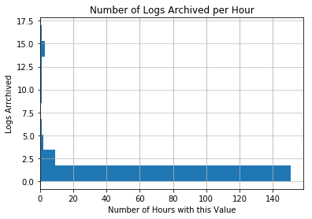

#### Log Buffer Sizing

```
 * db2+ibm_db://ecrooks:***@192.0.2.10:50001/SAMPLE1
Done.
Returning data to local variable logbuf_sizing
```

| log_reads | log_writes | log_read_write_ratio |
| --- | --- | --- |
| 52367 | 897971946 | 0.00005 |

## Database Maintenance

Database Maintenance for SAMPLE1 on SAMPLE1

### List of all Backups in History in the Last 14 days

```
 * db2+ibm_db://ecrooks:***@192.0.2.10:50001/SAMPLE1
Done.
Returning data to local variable backup_list
```

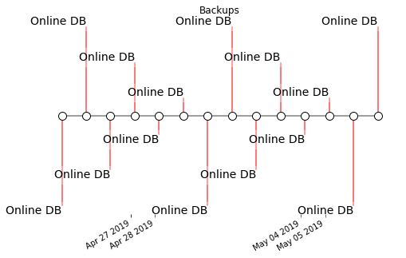

| start_date | start_time | start_timestamp | DAY | duration | TYPE | devicetype | sqlcode |
| --- | --- | --- | --- | --- | --- | --- | --- |
| 2019-04-24 | 04:00:04 | 20190424040004 | Wednesday | 41 | Online DB | D | None |
| 2019-04-25 | 04:00:03 | 20190425040003 | Thursday | 41 | Online DB | D | None |
| 2019-04-26 | 04:00:04 | 20190426040004 | Friday | 41 | Online DB | D | None |
| 2019-04-27 | 04:00:04 | 20190427040004 | Saturday | 41 | Online DB | D | None |
| 2019-04-28 | 04:00:03 | 20190428040003 | Sunday | 41 | Online DB | D | None |
| 2019-04-29 | 04:00:03 | 20190429040003 | Monday | 42 | Online DB | D | None |
| 2019-04-30 | 04:00:03 | 20190430040003 | Tuesday | 42 | Online DB | D | None |
| 2019-05-01 | 04:00:04 | 20190501040004 | Wednesday | 42 | Online DB | D | None |
| 2019-05-02 | 04:00:04 | 20190502040004 | Thursday | 42 | Online DB | D | None |
| 2019-05-03 | 04:00:04 | 20190503040004 | Friday | 41 | Online DB | D | None |
| 2019-05-04 | 04:00:03 | 20190504040003 | Saturday | 42 | Online DB | D | None |
| 2019-05-05 | 04:00:04 | 20190505040004 | Sunday | 41 | Online DB | D | None |
| 2019-05-06 | 04:00:04 | 20190506040004 | Monday | 41 | Online DB | D | None |
| 2019-05-07 | 04:00:04 | 20190507040004 | Tuesday | 41 | Online DB | D | None |

### Runstats

#### Last runstats date for non-system tables

```
 * db2+ibm_db://ecrooks:***@192.0.2.10:50001/SAMPLE1
Done.
Returning data to local variable last_stats
```

| stats_date | VOLATILE | num_tables |
| --- | --- | --- |
| 2018-09-09 | C | 8 |
| 2019-05-05 |  | 1310 |
| 2019-05-06 |  | 15 |
| 2019-05-07 |  | 91 |

#### Last runstats date for system tables

```
 * db2+ibm_db://ecrooks:***@192.0.2.10:50001/SAMPLE1
Done.
Returning data to local variable last_stats
```

| stats_month | stats_year | num_tables |
| --- | --- | --- |
| 5 | 2019 | 167 |

### Reorgs

#### Recent Reorgs

```
 * db2+ibm_db://ecrooks:***@192.0.2.10:50001/SAMPLE1
Done.
Returning data to local variable reorg_list
```

| start_date | start_time | tabschema | tabname | TYPE | sqlcode |
| --- | --- | --- | --- | --- | --- |
| 2019-04-28 | 05:17:46 | DB2INST1 | BUSEVENT | Online | None |
| 2019-04-28 | 05:17:46 | DB2INST1 | BUSPROF | Online | None |
| 2019-04-28 | 05:17:46 | DB2INST1 | CACHEIVL | Online | None |
| 2019-04-28 | 05:17:46 | DB2INST1 | CTXDATA | Online | None |
| 2019-04-28 | 05:17:46 | DB2INST1 | CTXMGMT | Online | None |
| 2019-04-28 | 05:17:46 | DB2INST1 | TI_ADATTR_2_2 | Online | None |
| 2019-04-28 | 05:17:46 | DB2INST1 | TI_ADATTR_2_2 | Online | None |
| 2019-04-28 | 05:17:47 | DB2INST1 | BUSPROF | Online | None |
| 2019-04-28 | 05:17:48 | DB2INST1 | CTXMGMT | Online | None |
| 2019-04-28 | 05:17:51 | DB2INST1 | CACHEIVL | Online | -911 |
| 2019-04-28 | 05:17:54 | DB2INST1 | CTXDATA | Online | None |
| 2019-04-28 | 05:17:57 | DB2INST1 | BUSEVENT | Online | None |
| 2019-04-28 | 05:18:37 | DB2INST1 | CTXDATA | Online | None |
| 2019-04-28 | 05:18:44 | DB2INST1 | CTXDATA | Online | None |
| 2019-04-28 | 05:18:51 | DB2INST1 | CTXMGMT | Online | None |
| 2019-04-28 | 05:18:56 | DB2INST1 | CTXMGMT | Online | None |
| 2019-04-28 | 05:19:02 | DB2INST1 | CTXMGMT | Online | None |
| 2019-04-28 | 05:19:12 | DB2INST1 | CTXMGMT | Online | None |
| 2019-04-28 | 05:19:12 | DB2INST1 | CTXMGMT | Online | None |
| 2019-04-28 | 05:19:19 | DB2INST1 | CTXMGMT | Online | None |
| 2019-04-28 | 05:19:30 | SYSIBM | SYSPLANDEP | Online | None |
| 2019-04-28 | 05:20:02 | DB2INST1 | CACHEIVL | Online | None |
| 2019-05-05 | 05:16:50 | DB2INST1 | BUSEVENT | Online | None |
| 2019-05-05 | 05:16:50 | DB2INST1 | BUSPROF | Online | None |
| 2019-05-05 | 05:16:50 | DB2INST1 | CACHEIVL | Online | None |
| 2019-05-05 | 05:16:51 | DB2INST1 | CTXDATA | Online | None |
| 2019-05-05 | 05:16:51 | DB2INST1 | BUSEVENT | Online | None |
| 2019-05-05 | 05:16:51 | DB2INST1 | CTXMGMT | Online | None |
| 2019-05-05 | 05:16:51 | DB2INST1 | TI_ADATTR_2_2 | Online | None |
| 2019-05-05 | 05:16:51 | DB2INST1 | TI_ADATTR_2_2 | Online | None |
| 2019-05-05 | 05:16:51 | DB2INST1 | BUSPROF | Online | None |
| 2019-05-05 | 05:16:52 | DB2INST1 | CTXMGMT | Online | None |
| 2019-05-05 | 05:16:55 | DB2INST1 | BUSEVENT | Online | None |
| 2019-05-05 | 05:16:56 | DB2INST1 | CTXDATA | Online | None |
| 2019-05-05 | 05:16:57 | DB2INST1 | CACHEIVL | Online | -911 |
| 2019-05-05 | 05:17:42 | DB2INST1 | CATGPCALCD | Online | None |
| 2019-05-05 | 05:17:48 | DB2INST1 | CATGPCALCD | Online | None |
| 2019-05-05 | 05:17:54 | DB2INST1 | CTXDATA | Online | None |
| 2019-05-05 | 05:18:00 | DB2INST1 | CTXDATA | Online | None |
| 2019-05-05 | 05:18:05 | DB2INST1 | CTXMGMT | Online | None |
| 2019-05-05 | 05:18:15 | DB2INST1 | CTXMGMT | Online | None |
| 2019-05-05 | 05:18:20 | DB2INST1 | CTXMGMT | Online | None |
| 2019-05-05 | 05:18:25 | DB2INST1 | CTXMGMT | Online | None |
| 2019-05-05 | 05:18:25 | DB2INST1 | CTXMGMT | Online | None |
| 2019-05-05 | 05:18:31 | DB2INST1 | CTXMGMT | Online | None |
| 2019-05-05 | 05:18:37 | DB2INST1 | DMACTIVITY | Online | None |
| 2019-05-05 | 05:18:37 | DB2INST1 | DMACTIVITY | Online | None |
| 2019-05-05 | 05:18:39 | DB2INST1 | ORDERITEMS | Online | None |
| 2019-05-05 | 05:18:53 | DB2INST1 | CACHEIVL | Online | None |
| 2019-05-05 | 05:19:43 | SYSIBM | SYSPLANDEP | Online | None |

#### Tables Needing Reorg

[output not shown]

```
 * db2+ibm_db://ecrooks:***@192.0.2.10:50001/SAMPLE1
Done.
Returning data to local variable tab_reorg_list
```

| table_schema | table_name | npages | card | reorg |
| --- | --- | --- | --- | --- |
| DB2INST1 | BUSEVENT | 1,142 | 2,318 | -** |
| DB2INST1 | BUSPROF | 2,512 | 90,225 | -*- |
| DB2INST1 | CACHEIVL | 95,488 | 5,817,615 | -** |
| DB2INST1 | CTXDATA | 6,487 | 238,734 | -** |
| DB2INST1 | CTXMGMT | 681 | 26,610 | -** |
| DB2INST1 | TI_ADATTR_2_2 | 1,101 | 279,520 | -*- |
| DBA | MY_LOCKS | 157 | 5,959 | -** |

```
 * db2+ibm_db://ecrooks:***@192.0.2.10:50001/SAMPLE1
Done.
Returning data to local variable ind_reorg_list
```

| table_schema | table_name | index_schema | index_name | nleaf | indcard | reorg |
| --- | --- | --- | --- | --- | --- | --- |
| DB2INST1 | CACHEIVL | DB2INST1 | I_CACHEIVL01 | 42,414 | 5,817,615 | --*-- |
| DB2INST1 | CTXDATA | DB2INST1 | I0000841 | 1,754 | 238,734 | -*--* |
| DB2INST1 | CTXDATA | SYSIBM | SQL120222200545160 | 12,822 | 238,734 | ----* |
| DB2INST1 | CTXMGMT | DB2INST1 | I0000831 | 484 | 26,610 | **-*- |
| DB2INST1 | CTXMGMT | DB2INST1 | I0000895 | 166 | 26,610 | -*-*- |
| DB2INST1 | CTXMGMT | DB2INST1 | I0000896 | 481 | 26,610 | **-*- |
| DB2INST1 | CTXMGMT | DB2INST1 | I0001299 | 444 | 26,610 | ----* |
| DB2INST1 | CTXMGMT | DB2INST1 | I0001545 | 1,071 | 26,610 | **-*- |
| DB2INST1 | CTXMGMT | SYSIBM | SQL120222200545180 | 409 | 26,610 | -*-** |
| DB2INST1 | PX_ELEMENT | DB2INST1 | I0001201 | 1,007 | 55,881 | ---*- |
| DB2INST1 | PX_ELEMENT | SYSIBM | SQL120222200552440 | 534 | 55,881 | ---*- |
| DB2INST1 | PX_ELEMENTNVP | DB2INST1 | I0001197 | 1,190 | 63,714 | ---*- |
| DB2INST1 | PX_ELEMENTNVP | SYSIBM | SQL120222200552460 | 587 | 63,714 | ---*- |
| DB2INST1 | TKLACTHIST | SYSIBM | SQL120222200556150 | 315 | 32,134 | *--*- |
| DB2INST1 | USERS | DB2INST1 | I348118 | 45,979 | 4,362,296 | *--*- |
| DB2INST1 | X_REVIEW | SYSIBM | SQL170319034142720 | 32 | 7,878 | *--*- |
| SYSIBM | SYSCOLDIST | SYSIBM | INDCOLDIST01 | 7,835 | 359,160 | ---*- |
| SYSIBM | SYSROUTINEPARMS | SYSIBM | INDROUTINEPARMS06 | 268 | 11,995 | ---*- |

## SQL Analysis

Only indicators that SQL analysis is needed are calculated here. Separate notebooks are used for identifying and analyzing problem SQL.

### Index Read Efficiency

```
 * db2+ibm_db://ecrooks:***@192.0.2.10:50001/SAMPLE1
Done.
Returning data to local variable ixref
```

```
Index read efficiency is not great but not horrible for an OLTP database at 70
```

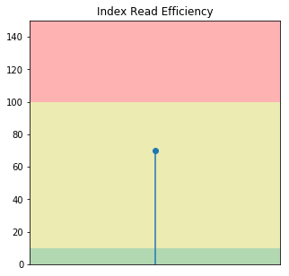

## Memory Picture for Whole Server

This section is designed to be used with a multi-instance server and does not apply to all environments. At least on Linux, Db2 often over-allocates memory for multiple instances

### Total Memory on server

```
 * db2+ibm_db://ecrooks:***@192.0.2.10:50001/SAMPLE1
Done.
```

| mem_tot_gb |
| --- |
| 503.61 |

### Portion of Server Memory this Instance Represents

```
 * db2+ibm_db://ecrooks:***@192.0.2.10:50001/SAMPLE1
Done.
```

| instance_memory_gb |
| --- |
| 200.00 |